# Capstone_Project_Report_Cyclist

Mubashir Ul Hassan

09 February, 2024

## 1. **Introduction**

Cyclistic, a bike share company based in Chicago, aims to enhance its marketing strategy and foster future growth by understanding user behavior. Assigned with a case study during the Google Data Analytics certification course, I am tasked with analyzing Cyclistic’s historical bike trip data to provide actionable insights for the company’s marketing strategy.

## 2. **Scenario**

With over 5,800 bicycles and 600 docking stations across the city, Cyclistic targets both casual riders and annual members. Lily Moreno, the Director of Marketing, seeks to convert casual riders into annual members through targeted marketing campaigns. Understanding the behavior and preferences of these user groups is crucial. Cyclistic’s marketing analytics team is entrusted with analyzing past user data to identify trends and habits, ultimately aiding in crafting effective marketing strategies.

# 3. **Phase 1: Ask**

## 3.0.1 Business Objective

The objective is to identify opportunities for targeted marketing campaigns to convert casual riders into annual members, thereby increasing profitability and driving growth.

## 3.0.2 Business Task

Tasks include analyzing historical bike trip data, identifying usage trends between casual and member riders, and leveraging insights to develop targeted marketing campaigns.

## 3.0.3 Stakeholders

Key stakeholders include Lily Moreno, Cyclistic’s marketing team, casual riders, annual members, and investors/shareholders.

# 4. **Phase 2: Prepare**

## 4.0.3 Data Credibility

Collected by Motivate, Inc., the data is comprehensive, consistent, and current. Identifying information has been removed to ensure user privacy.

## 4.0.4 Licensing, Privacy, Security, and Accessibility

The data is released under a specific license and is publicly accessible. Privacy measures have been taken to safeguard user information.

## 4.0.5 Ability of Data to Answer Business Questions

The dataset sufficiently addresses the business questions regarding usage patterns between annual members and casual riders.

## 4.0.6 Challenges with the Data

Challenges included data cleaning, handling large data volume, and utilizing specialized tools like R and Tableau for analysis.

# 5. **Phase 3: Data Process**

## 5.0.1 Choice of Tools

RStudio Desktop and Tableau were chosen for efficient data preparation, processing, analysis, and visualization due to their capabilities and handling of large datasets.

## 5.0.2 Data Review

An initial review assessed variables, data format, integrity, and potential issues, leading to the consolidation of 12 monthly files into one dataset. Identified anomalies were addressed to ensure data quality.

## install packages

```r
#----------------------------------------------------------------------------------#
install.packages("tidyverse")
install.packages("lubridate")
install.packages("janitor")
install.packages("data.table")
install.packages("readr")
install.packages("psych")
install.packages("hrbrthemes")
install.packages("ggplot2")
#----------------------------------------------------------------------------------#
```

## load packages

```r
#----------------------------------------------------------------------------------#
library(tidyverse)
library(lubridate)
library(janitor)
library(data.table)
library(readr)
library(psych)
library(hrbrthemes)
library(ggplot2)
#----------------------------------------------------------------------------------#
```

## import data

```r
#----------------------------------------------------------------------------------#
january_2023 <- read.csv("data/202301-divvy-tripdata.csv")
february_2023 <- read.csv("data/202302-divvy-tripdata.csv")
march_2023 <- read.csv("data/202303-divvy-tripdata.csv")
april_2023 <- read.csv("data/202304-divvy-tripdata.csv")
may_2023 <- read.csv("data/202305-divvy-tripdata.csv")
june_2023 <- read.csv("data/202306-divvy-tripdata.csv")
july_2023 <- read.csv("data/202307-divvy-tripdata.csv")
august_2023 <- read.csv("data/202308-divvy-tripdata.csv")
september_2023 <- read.csv("data/202309-divvy-tripdata.csv")
october_2023 <- read.csv("data/202310-divvy-tripdata.csv")
november_2023 <- read.csv("data/202311-divvy-tripdata.csv")
december_2023 <- read.csv("data/202312-divvy-tripdata.csv")
#----------------------------------------------------------------------------------#
```

## data validation

```r
#----------------------------------------------------------------------------------#
colnames(january_2023)
colnames(february_2023)
colnames(march_2023)
colnames(april_2023)
colnames(may_2023)
colnames(june_2023)
colnames(july_2023)
colnames(august_2023)
colnames(september_2023)
colnames(october_2023)
colnames(november_2023)
colnames(december_2023)
#----------------------------------------------------------------------------------#
```

## total number of rows

```r
#----------------------------------------------------------------------------------#
sum(nrow(january_2023) + nrow(february_2023) + nrow(march_2023) +
  nrow(april_2023) + nrow(may_2023) + nrow(june_2023) + nrow(july_2023)+
  nrow(august_2023) + nrow(september_2023) + nrow(october_2023) +
  nrow(november_2023) + nrow(december_2023))
#----------------------------------------------------------------------------------#
```

## combine data of 12 month into one for smooth work flow

```r
#----------------------------------------------------------------------------------#
tripfinal <- rbind(january_2023, february_2023, march_2023, april_2023,
                   may_2023, june_2023, july_2023, august_2023, september_2023,
                   october_2023,november_2023,december_2023)
#----------------------------------------------------------------------------------#
```

## save the combined files

```r
#----------------------------------------------------------------------------------#
write.csv(tripfinal, file = "data/tripfinal.csv", row.names = FALSE)
#----------------------------------------------------------------------------------#
```

## final data validation

```r
#----------------------------------------------------------------------------------#
str(tripfinal)
View(head(tripfinal))
View(tail(tripfinal))
dim(tripfinal)
summary(tripfinal)
names(tripfinal)
#----------------------------------------------------------------------------------#
```

# 6. **Phase 4: Data Cleaning**

During this phase, I conducted data cleaning procedures to rectify errors or inconsistencies within the dataset. These procedures encompassed various techniques, including rectifying data entry errors, eliminating duplicates or erroneous records, and standardizing data formats to ensure compatibility with analysis tools. Data cleaning is pivotal in ensuring the accuracy and reliability of the data, thereby yielding meaningful and actionable insights.

Prior to commencing the data cleaning process, it was imperative to assess the total number of rows containing missing or “NA” values. This assessment provided insights into the extent of missing or incomplete data, guiding decisions on how to address these values, whether through elimination from the dataset or imputation with estimates or substitute values.

## count rows with “na” values

```r
#----------------------------------------------------------------------------------#
colSums(is.na(tripfinal))
#----------------------------------------------------------------------------------#
```

## remove missing

```r
#----------------------------------------------------------------------------------#
clean_trip_final <- tripfinal[complete.cases(tripfinal), ]
#----------------------------------------------------------------------------------#
```

## remove duplicates

```r
#----------------------------------------------------------------------------------#
clean_trip_final <- distinct(clean_trip_final)
#----------------------------------------------------------------------------------#
```

## remove “na”

```r
#----------------------------------------------------------------------------------#
clean_trip_final <- drop_na(clean_trip_final)
clean_trip_final <- remove_empty(clean_trip_final)
clean_trip_final <- remove_missing(clean_trip_final)
#----------------------------------------------------------------------------------#
```

## remove data which greater start_at then end_at

```r
#----------------------------------------------------------------------------------#
clean_trip_final <- clean_trip_final %>%
  filter(started_at < ended_at)
#----------------------------------------------------------------------------------#
```

## remaining column for better context

```r
#----------------------------------------------------------------------------------#
clean_trip_final <- rename(clean_trip_final, costumer_type = member_casual,
                           bike_type = rideable_type)
#----------------------------------------------------------------------------------#
```

## separate date in date, month, year for better analysis

```r
#----------------------------------------------------------------------------------#
clean_trip_final$date <- as.Date(clean_trip_final$started_at)
clean_trip_final$week_day <- format(as.Date(clean_trip_final$date), "%A")
clean_trip_final$month <- format(as.Date(clean_trip_final$date), "%b_%y")
clean_trip_final$year <- format(clean_trip_final$date, "%Y")
#----------------------------------------------------------------------------------#
```

## separate column for time

```r
#----------------------------------------------------------------------------------#
clean_trip_final$time <- as.POSIXct(clean_trip_final$started_at , format = "%Y-%m-%d %H:%M:%S")
clean_trip_final$time <- format(clean_trip_final$time, format = "%H:%M")
#----------------------------------------------------------------------------------#
```

## add right length column

```r
#----------------------------------------------------------------------------------#
clean_trip_final$ride_length <- difftime(clean_trip_final$ended_at, clean_trip_final$started_at, units = "mins")
#----------------------------------------------------------------------------------#
```

## select the data we are going to use

```r
#----------------------------------------------------------------------------------#
clean_trip_final <- clean_trip_final %>%
  select(bike_type, costumer_type, month, year, time, started_at, week_day, ride_length)
#----------------------------------------------------------------------------------#
```

## remove stolen bikes

```r
#----------------------------------------------------------------------------------#
clean_trip_final <- clean_trip_final[!clean_trip_final$ride_length>1440,]
clean_trip_final <- clean_trip_final[!clean_trip_final$ride_length<5,]
#----------------------------------------------------------------------------------#
```

## checked cleaned data

```r
#----------------------------------------------------------------------------------#
colSums(is.na(clean_trip_final))
View(filter(clean_trip_final, clean_trip_final$started_at > clean_trip_final$ended_at))
View(filter(clean_trip_final, clean_trip_final$ride_length>1440 | clean_trip_final < 5))
#----------------------------------------------------------------------------------#
```

## save the cleaned data

```r
#----------------------------------------------------------------------------------#
write.csv(clean_trip_final, file = "clean_trip_final.csv", row.names = FALSE)
#----------------------------------------------------------------------------------#
```

# 7. **Phase 5: Data Analysis**

To kickstart the analysis phase, I imported the meticulously cleaned and prepared trip data into my analysis software. Subsequently, I rigorously validated the data to ensure its accuracy and reliability, laying a robust foundation for subsequent analysis.

## import the cleaned data

```r
#----------------------------------------------------------------------------------#
clean_trip_final <- read.csv("clean_trip_final.csv")
str(clean_trip_final)
names(clean_trip_final)
#----------------------------------------------------------------------------------#
```

## order the data

```r
#----------------------------------------------------------------------------------#
clean_trip_final$month <- ordered(clean_trip_final$month,levels=c("Jan_23","Feb_23","Mar_23",
                                                                  "Apr_23","May_23","Jun_23","Jul_23",
                                                                  "Aug_23","Sep_23","Oct_23","Nov_23","Dec_23"))

clean_trip_final$week_day <- ordered(clean_trip_final$week_day,levels=c("Sunday", "Monday", "Tuesday", "Wednesday", "Thursday", "Friday", "Saturday"))
#----------------------------------------------------------------------------------#
```

## analysis:- min, max, median, average

```r
#----------------------------------------------------------------------------------#
View(describe(clean_trip_final, fast=TRUE))
#----------------------------------------------------------------------------------#
```

## total number of customer

```r
#----------------------------------------------------------------------------------#
View(table(clean_trip_final$costumer_type))
#----------------------------------------------------------------------------------#
```

## total rides for each customer type in minutes

```r
#----------------------------------------------------------------------------------#
View(setNames(aggregate(ride_length ~ costumer_type, clean_trip_final, sum ),c("Customer_type", "total_ride_len(mins)")))
#----------------------------------------------------------------------------------#
```

## difference between members and casual riders in terms of length of ride

```r
#----------------------------------------------------------------------------------#
View(clean_trip_final %>%
       group_by(costumer_type) %>%
       summarise(min_length_mins = min(ride_length), max_length_min = max(ride_length),
                 median_length_mins = median(ride_length), mean_length_min = mean(ride_length)))
#----------------------------------------------------------------------------------#
```

## average ride_length for users by day_of_week and numbers of total riders by day_of_week

```r
#----------------------------------------------------------------------------------#
View(clean_trip_final %>%
       group_by(week_day) %>%
       summarise(Avg_length = mean(ride_length),
                 number_of_ride = n()))
#----------------------------------------------------------------------------------#
```

## average ride length comparison by each week day according to each customer type

```r
#----------------------------------------------------------------------------------#
View(aggregate(clean_trip_final$ride_length ~ clean_trip_final$costumer_type+
                 clean_trip_final$week_day, FUN = mean))
#----------------------------------------------------------------------------------#
```

## analyze rider length data by customer type and weekday

```r
#----------------------------------------------------------------------------------#
View(clean_trip_final %>%
       group_by(costumer_type, week_day) %>%
       summarise(number_of_ride = n(),
                 avgerage_duration = mean(ride_length),
                 median_duration = median(ride_length),
                 max_duration = max(ride_length),
                 min_duration = min(ride_length)))
#----------------------------------------------------------------------------------#
```

## save the data for data visualization

```r
#----------------------------------------------------------------------------------#
write.csv(clean_trip_final,file = "clean_trip_final_tableau.csv",row.names = FALSE)
#----------------------------------------------------------------------------------#
```

# 8. **Phase 6: Data Visualizations and Summary**

## 8.0.1 Visualization 1

The visualization illustrates the total number of rides per day of the week for each customer type. Casual riders exhibit higher ride numbers on weekends, suggesting leisurely use, while members maintain consistent ride numbers throughout the week, possibly indicating commute-related usage.

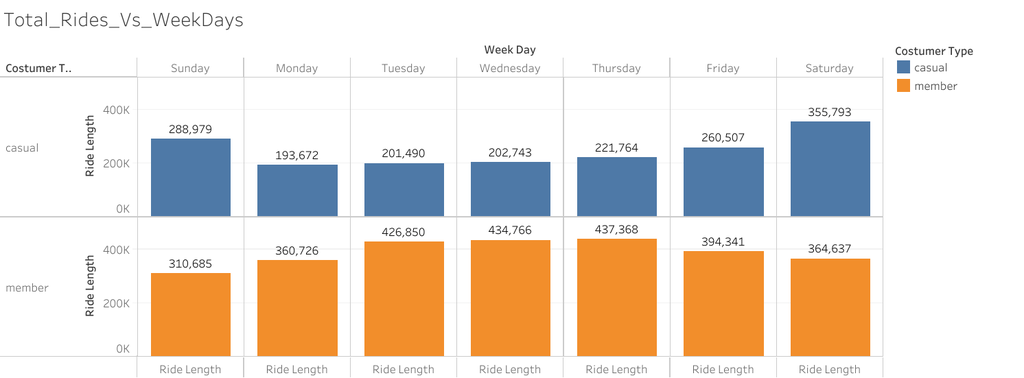

## 8.0.2 Visualization 2

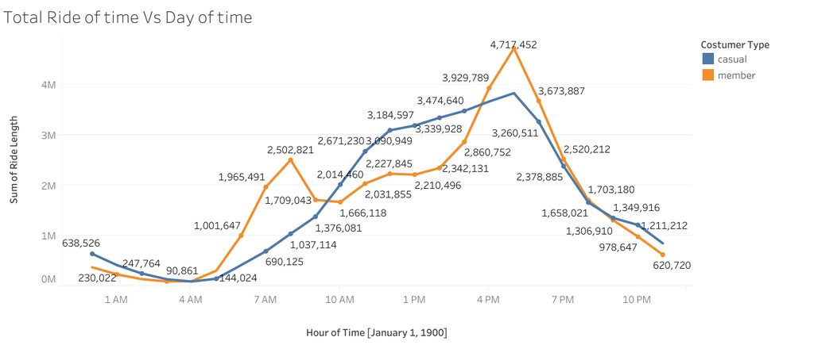

## 8.0.3 Visualization 3

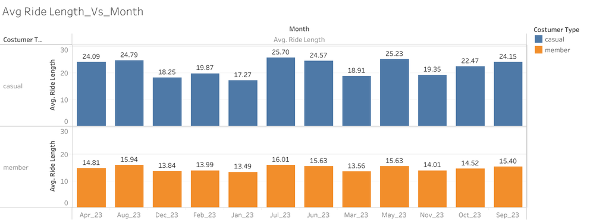

## 8.0.4 Visualization 4

Analysis of ride duration by weekdays reveals casual riders’ weekend preference for leisure, contrasting with members’ consistent usage. This insight aids in marketing segmentation and pricing strategies.

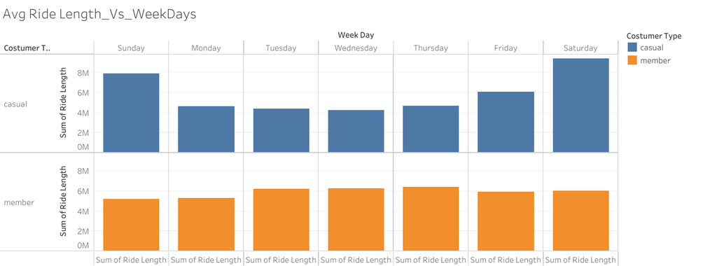

## 8.0.5 Visualization 5

Overall, annual members prioritize commuting, maintaining steady usage, while casual riders favor weekend leisure activities, leading to longer average ride durations. These findings inform business strategies and service improvements.

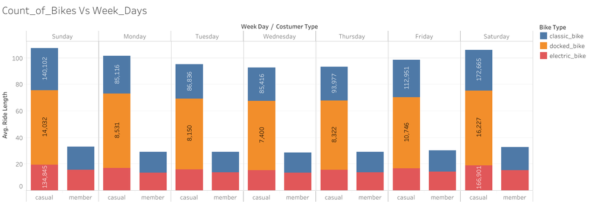

## 8.0.6 Visualization 6

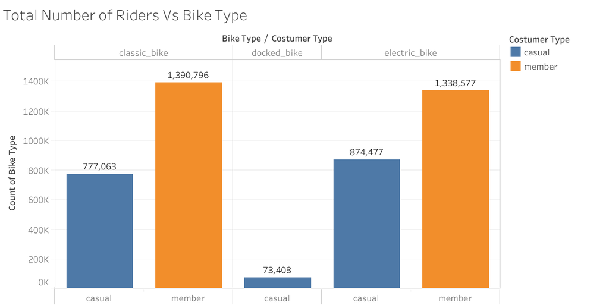

## 8.0.7 Visualization 7

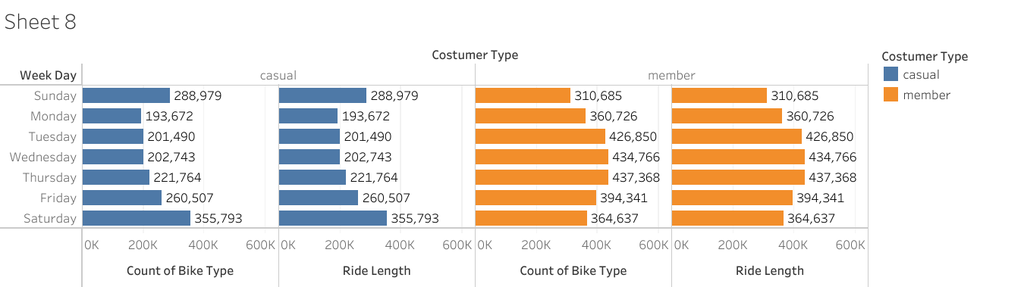

# 9. **Phase 7: Act**

# 9.0.2 **Recommendations**

- Target leisure riders with summer weekend promotions to boost revenue.
- Incentivize regular member usage through discounts and perks.
- Investigate reasons for docked bike unpopularity and consider improvements.
- Enhance classic bike offerings based on user preferences.
- Offer extended rental options for casual riders to capitalize on longer rides.
- Ramp up winter marketing for casual riders to mitigate seasonal fluctuations.